# Project: Investigate a Dataset - Medical appointments no shows

## Contents Table

- 1. Introduction
  - 1.1 Questions
  - 1.2 Read and analysis data structure
- 2.Wrangling
- 3.Exploratory data
  - 3.1 General show rate
  - 3.2 Show rate by age
  - 3.3 Show rate by gender
  - 3.4 Show rate by interval
  - 3.5 Show rate by neighbourhood
  - 3.6 Show rate by scholarship
  - 3.7 Show rate by SMS_received
  - 3.8 Show rate by diseases
  - 3.9 Show distribution related to diseases/age/scholarship
  - 3.10 Show distribution related to diseases/interval/scholarship
- 4.Conclusions
- 5.Limitations

## 1. Introduction

### 1.1 Questions

- 1 Which single features show high correlation with show rate and the range of itself?
- 2 What is characteristics and correlation that factors of diseases,age and scholarship can influence show-up paitients distribution ?
- 3 What is characteristics and correlation that factors of diseases,interval and scholarship can influence show-up paitients distribution ?

### 1.2 Read and analysis data structure

```python
# Import the neccessary packages
import pandas as pd
import matplotlib as plt
% matplotlib inline
import numpy as np
import matplotlib.pyplot as plt
import missingno as msno
import seaborn as sns
```

```python
# Load relevant .csv files into DataFrames
df = pd.read_csv('noshowappointments-kagglev2-may-2016.csv')
df.head()
```

|  | PatientId | AppointmentID | Gender | ScheduledDay | AppointmentDay | Age | Neighbourhood | Scholarship | Hipertension | Diabetes | Alcoholism | Handcap | SMS_received | No-show |
| --- | --- | --- | --- | --- | --- | --- | --- | --- | --- | --- | --- | --- | --- | --- |
| 0 | 2.987250e+13 | 5642903 | F | 2016-04-29T18:38:08Z | 2016-04-29T00:00:00Z | 62 | JARDIM DA PENHA | 0 | 1 | 0 | 0 | 0 | 0 | No |
| 1 | 5.589978e+14 | 5642503 | M | 2016-04-29T16:08:27Z | 2016-04-29T00:00:00Z | 56 | JARDIM DA PENHA | 0 | 0 | 0 | 0 | 0 | 0 | No |
| 2 | 4.262962e+12 | 5642549 | F | 2016-04-29T16:19:04Z | 2016-04-29T00:00:00Z | 62 | MATA DA PRAIA | 0 | 0 | 0 | 0 | 0 | 0 | No |
| 3 | 8.679512e+11 | 5642828 | F | 2016-04-29T17:29:31Z | 2016-04-29T00:00:00Z | 8 | PONTAL DE CAMBURI | 0 | 0 | 0 | 0 | 0 | 0 | No |
| 4 | 8.841186e+12 | 5642494 | F | 2016-04-29T16:07:23Z | 2016-04-29T00:00:00Z | 56 | JARDIM DA PENHA | 0 | 1 | 1 | 0 | 0 | 0 | No |

```python
# check missing values/data types/the numbers of columns and rows.
df.info()
```

```
<class 'pandas.core.frame.DataFrame'>
RangeIndex: 110527 entries, 0 to 110526
Data columns (total 14 columns):
PatientId         110527 non-null float64
AppointmentID     110527 non-null int64
Gender            110527 non-null object
ScheduledDay      110527 non-null object
AppointmentDay    110527 non-null object
Age               110527 non-null int64
Neighbourhood     110527 non-null object
Scholarship       110527 non-null int64
Hipertension      110527 non-null int64
Diabetes          110527 non-null int64
Alcoholism        110527 non-null int64
Handcap           110527 non-null int64
SMS_received      110527 non-null int64
No-show           110527 non-null object
dtypes: float64(1), int64(8), object(5)
memory usage: 11.8+ MB
```

- It is clear that there is no missing value in the dataframe.

## 2.Wrangling

```python
# replace the column name with Show_rate and check the result.
df = df.rename(columns = {'No-show':'Show_rate'})
df.columns
```

```
Index(['PatientId', 'AppointmentID', 'Gender', 'ScheduledDay',
       'AppointmentDay', 'Age', 'Neighbourhood', 'Scholarship', 'Hipertension',
       'Diabetes', 'Alcoholism', 'Handcap', 'SMS_received', 'Show_rate'],
      dtype='object')
```

```python
# reolace the column value with 0 or 1 and check the result.
# the Show_rate data uses 1 or 0 to represent the show condition, so the mean of "Show_rate" column is actually the Show rate.
df['Show_rate'] = df['Show_rate'].replace('No',1)
df['Show_rate'] = df['Show_rate'].replace('Yes',0)
df.head()
```

|  | PatientId | AppointmentID | Gender | ScheduledDay | AppointmentDay | Age | Neighbourhood | Scholarship | Hipertension | Diabetes | Alcoholism | Handcap | SMS_received | Show_rate |
| --- | --- | --- | --- | --- | --- | --- | --- | --- | --- | --- | --- | --- | --- | --- |
| 0 | 2.987250e+13 | 5642903 | F | 2016-04-29T18:38:08Z | 2016-04-29T00:00:00Z | 62 | JARDIM DA PENHA | 0 | 1 | 0 | 0 | 0 | 0 | 1 |
| 1 | 5.589978e+14 | 5642503 | M | 2016-04-29T16:08:27Z | 2016-04-29T00:00:00Z | 56 | JARDIM DA PENHA | 0 | 0 | 0 | 0 | 0 | 0 | 1 |
| 2 | 4.262962e+12 | 5642549 | F | 2016-04-29T16:19:04Z | 2016-04-29T00:00:00Z | 62 | MATA DA PRAIA | 0 | 0 | 0 | 0 | 0 | 0 | 1 |
| 3 | 8.679512e+11 | 5642828 | F | 2016-04-29T17:29:31Z | 2016-04-29T00:00:00Z | 8 | PONTAL DE CAMBURI | 0 | 0 | 0 | 0 | 0 | 0 | 1 |
| 4 | 8.841186e+12 | 5642494 | F | 2016-04-29T16:07:23Z | 2016-04-29T00:00:00Z | 56 | JARDIM DA PENHA | 0 | 1 | 1 | 0 | 0 | 0 | 1 |

```python
# check for any erroneous values about every column and show the result.
print('Gender:%s' % df['Gender'].unique())
print('Age:%s' % sorted(df['Age'].unique()))
print('Scholarship:%s' % df['Scholarship'].unique())
print('Hipertension:%s' % df['Hipertension'].unique())
print('Diabetes:%s' % df['Diabetes'].unique())
print('Alcoholism:%s' % df['Alcoholism'].unique())
print('Handcap:%s' % df['Handcap'].unique())
print('SMS_received:%s' % df['SMS_received'].unique())
print('Show_rate:%s' % df['Show_rate'].unique())
```

```
Gender:['F' 'M']
Age:[-1, 0, 1, 2, 3, 4, 5, 6, 7, 8, 9, 10, 11, 12, 13, 14, 15, 16, 17, 18, 19, 20, 21, 22, 23, 24, 25, 26, 27, 28, 29, 30, 31, 32, 33, 34, 35, 36, 37, 38, 39, 40, 41, 42, 43, 44, 45, 46, 47, 48, 49, 50, 51, 52, 53, 54, 55, 56, 57, 58, 59, 60, 61, 62, 63, 64, 65, 66, 67, 68, 69, 70, 71, 72, 73, 74, 7…
Scholarship:[0 1]
Hipertension:[1 0]
Diabetes:[0 1]
Alcoholism:[0 1]
Handcap:[0 1 2 3 4]
SMS_received:[0 1]
Show_rate:[1 0]
```

- The Age column values ranges from -1 to 115 which need to be modified. The value should be above 0 and below 100,because the sample age distribution focuse on this range.The graph below is a the proof.
- The Handcap column values ranges from 0 to 4 which need to be modified. The value should be either 0 or 1,because the number of diseases appointment should be one at most.

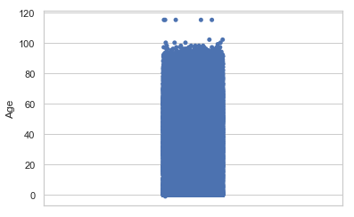

```python
# show the sample age distribution
sns.set(style="whitegrid")
ax = sns.stripplot(data = df, y = 'Age',jitter=True)
```

```python
# remove the impossible and the absurd from the data and check the result.
df = df[(df['Age'] >= 0) & (df['Age'] <= 100)]
print('Age:%s' % sorted(df['Age'].unique()))
```

```
Age:[0, 1, 2, 3, 4, 5, 6, 7, 8, 9, 10, 11, 12, 13, 14, 15, 16, 17, 18, 19, 20, 21, 22, 23, 24, 25, 26, 27, 28, 29, 30, 31, 32, 33, 34, 35, 36, 37, 38, 39, 40, 41, 42, 43, 44, 45, 46, 47, 48, 49, 50, 51, 52, 53, 54, 55, 56, 57, 58, 59, 60, 61, 62, 63, 64, 65, 66, 67, 68, 69, 70, 71, 72, 73, 74, 75, 7…
```

```python
# replace the absurd value with the reasonable value and check the result.
df['Handcap'] = df['Handcap'].replace([2,3,4],1)
df['Handcap'].unique()
```

```
array([0, 1], dtype=int64)
```

```python
# replace the columns number values with literal string to show the graph conveniently and check the result.
for col in ['Hipertension','Diabetes','Alcoholism','Handcap']:
    df[col] = df[col].replace(1,'Yes')
    df[col] = df[col].replace(0,'No')
for col in ['Scholarship','SMS_received']:
    df[col] = df[col].replace(1,'Have')
    df[col] = df[col].replace(0,'None')
df.head()
```

|  | PatientId | AppointmentID | Gender | ScheduledDay | AppointmentDay | Age | Neighbourhood | Scholarship | Hipertension | Diabetes | Alcoholism | Handcap | SMS_received | Show_rate |
| --- | --- | --- | --- | --- | --- | --- | --- | --- | --- | --- | --- | --- | --- | --- |
| 0 | 2.987250e+13 | 5642903 | F | 2016-04-29T18:38:08Z | 2016-04-29T00:00:00Z | 62 | JARDIM DA PENHA | None | Yes | No | No | No | None | 1 |
| 1 | 5.589978e+14 | 5642503 | M | 2016-04-29T16:08:27Z | 2016-04-29T00:00:00Z | 56 | JARDIM DA PENHA | None | No | No | No | No | None | 1 |
| 2 | 4.262962e+12 | 5642549 | F | 2016-04-29T16:19:04Z | 2016-04-29T00:00:00Z | 62 | MATA DA PRAIA | None | No | No | No | No | None | 1 |
| 3 | 8.679512e+11 | 5642828 | F | 2016-04-29T17:29:31Z | 2016-04-29T00:00:00Z | 8 | PONTAL DE CAMBURI | None | No | No | No | No | None | 1 |
| 4 | 8.841186e+12 | 5642494 | F | 2016-04-29T16:07:23Z | 2016-04-29T00:00:00Z | 56 | JARDIM DA PENHA | None | Yes | Yes | No | No | None | 1 |

- The rows of which datetime of AppointmentDay is earlier than ScheduledDay that is illogical need to be removed .To convert the AppointmentDay and ScheduledDay columns into datetime64 format and calculate difference of AppointmentDay and ScheduledDay as column Interval value is necessary.

```python
# remove the unreasonable rows which datetime of AppointmentDay is earlier than ScheduledDay.
df_val = df[df['ScheduledDay'] <= df['AppointmentDay']].copy()
# convert the datatype of object into datetime64
df_val['ScheduledDay'] = pd.to_datetime(df_val['ScheduledDay'])
df_val['AppointmentDay'] = pd.to_datetime(df_val['AppointmentDay'])
# calculate difference of  AppointmentDay and ScheduledDay as column Interval value.
df_val['Interval'] = (df_val['AppointmentDay'] - df_val['ScheduledDay']).dt.days
df_val.dtypes
```

```
PatientId                float64
AppointmentID              int64
Gender                    object
ScheduledDay      datetime64[ns]
AppointmentDay    datetime64[ns]
Age                        int64
Neighbourhood             object
Scholarship               object
Hipertension              object
Diabetes                  object
Alcoholism                object
Handcap                   object
SMS_received              object
Show_rate                  int64
Interval                   int64
dtype: object
```

```python
#check the number of duplicate rows.
sum(df_val.duplicated())
```

```
0
```

## 3.Exploratory Data

### 3.1 General show rate

- Check how the likelihood that show up in general

```python
# calculate and show the ratio of show-up in general.
total_show = df_val['Show_rate'].sum()
total_no_show = df_val['Show_rate'].count() - df_val['Show_rate'].sum()
```

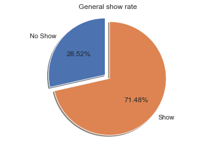

```python
explode = [0,0.10]
plt.pie([total_no_show, total_show], shadow=True, startangle=90, labels=['No Show','Show'],autopct='%1.2f%%',explode=explode)
plt.title('General show rate')
plt.axis('equal')
plt.show()
```

- 28.52% of patients miss their scheduled appointments in general.

### 3.2 Show rate by age

- Check how the likelihood that show up changes with respect to age

```
count    100.000000
mean       0.729359
std        0.076152
min        0.500000
25%        0.675650
50%        0.726136
75%        0.782052
max        1.000000
Name: Show_rate, dtype: float64
```

```
Text(0.5,1,'Show rate of age')
```

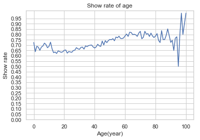

```python
# calculate and show the likelihood of show with respect to age.
print(df_val.groupby(['Age']).mean()['Show_rate'].describe())
df_val.groupby(['Age']).mean()['Show_rate'].plot(kind='line',grid=True)
plt.yticks(np.arange(0,1,0.05))
plt.xlabel('Age(year)')
plt.ylabel('Show rate')
plt.title('Show rate of age')
```

- The show rate change significantly stronger with respect to age from 0 to 100 yeas old.

### 3.3 Show rate by gender

- Check how the likelihood that show up changes with respect to gender.

```
Gender
F    0.715573
M    0.713341
Name: Show_rate, dtype: float64
```

```
 <a list of 11 Text yticklabel objects>)
```

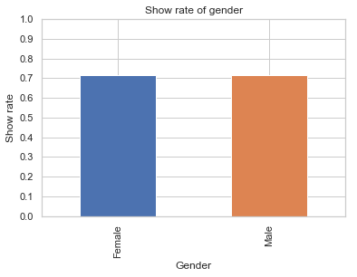

```python
# calculate and show the likelihood of show with respect to gender.
print(df_val.groupby(['Gender']).mean()['Show_rate'])
df_val.groupby(['Gender']).mean()['Show_rate'].rename({'F':'Female','M':'Male'}).plot(kind='bar',grid=True)
plt.xlabel('Gender')
plt.ylabel('Show rate')
plt.title('Show rate of gender')
plt.yticks(np.arange(0,1.1,0.1))
```

- The show rate changes not obviously with respect to gender.Both the male and the female have the same show rate 71%.

### 3.4 Show rate by interval

- show the sample interval distribution

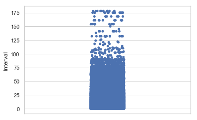

```python
# show the sample interval distribution
sns.set(style="whitegrid")
ax = sns.stripplot(data = df_val, y = 'Interval',jitter=True)
```

- The graph above shows that the sample interval distributes between 0 and 100 days.
- Check how the likelihood that show up changes with respect to interval.

```
count    128.000000
mean       0.699279
std        0.197097
min        0.000000
25%        0.640417
50%        0.688578
75%        0.772222
max        1.000000
Name: Show_rate, dtype: float64
```

```
 <a list of 11 Text yticklabel objects>)
```

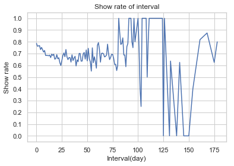

```python
# calculate and show the likelihood of show with respect to gender.
print(df_val.groupby(['Interval']).mean()['Show_rate'].describe())
# plt.figure(figsize= (18 ,5))
df_val.groupby(['Interval']).mean()['Show_rate'].plot(kind='line')
plt.xlabel('Interval(day)')
plt.ylabel('Show rate')
plt.title('Show rate of interval')
plt.yticks(np.arange(0,1.1,0.1))
```

- The show rate change significantly stronger with respect to interval especially between 0 and 100 days.

### 3.5 Show rate by neighbourhood

- Check how the likelihood that show up changes with respect to neighbourhood.

```
count    80.000000
mean      0.717290
std       0.092722
min       0.000000
25%       0.702302
50%       0.723929
75%       0.748180
max       0.913043
Name: Show_rate, dtype: float64
```

```
 <a list of 11 Text yticklabel objects>)
```

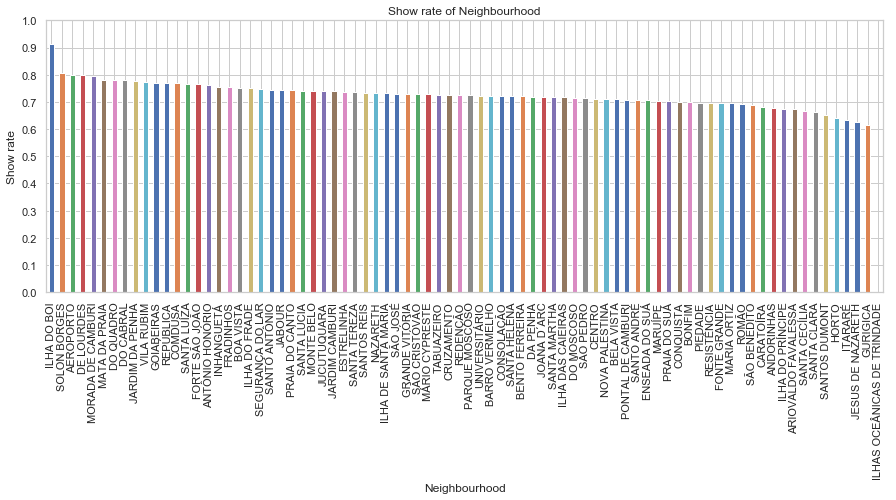

```python
# calculate and show the likelihood of show with respect to neighbourhood.
print(df_val.groupby(['Neighbourhood']).mean()['Show_rate'].describe())
plt.figure(figsize= (15 ,5))
df_val.groupby(['Neighbourhood']).mean()['Show_rate'].sort_values(ascending=False).plot(kind='bar',grid=True)
plt.xlabel('Neighbourhood')
plt.ylabel('Show rate')
plt.title('Show rate of Neighbourhood')
plt.yticks(np.arange(0,1.1,0.1))
```

- The show rate changes significantly with respect to neighbourhood and ranges mainly from 0.6 to 0.8.

### 3.6 Show rate by scholarship

- Check how the likelihood that show up changes with respect to scholarship.

```
Scholarship
Have    0.650277
None    0.721428
Name: Show_rate, dtype: float64
```

```
 <a list of 11 Text yticklabel objects>)
```

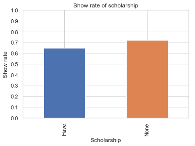

```python
# calculate and show the likelihood of show with respect to scholarship.
print(df_val.groupby(['Scholarship']).mean()['Show_rate'])
df_val.groupby(['Scholarship']).mean()['Show_rate'].rename({0:'None',1:'Have'}).plot(kind='bar',grid=True)
plt.xlabel('Scholarship')
plt.ylabel('Show rate')
plt.title('Show rate of scholarship')
plt.yticks(np.arange(0,1.1,0.1))
```

### 3.7 Show rate by SMS_received

- Check how the likelihood that show up changes with respect to SMS_received.

```
SMS_received
Have    0.724247
None    0.705673
Name: Show_rate, dtype: float64
```

```
 <a list of 11 Text yticklabel objects>)
```

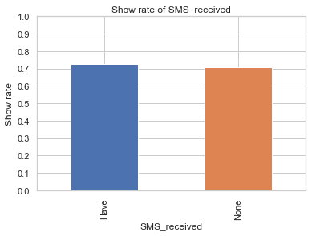

```python
# calculate and show the likelihood of show with respect to SMS_received.
print(df_val.groupby(['SMS_received']).mean()['Show_rate'])
df_val.groupby(['SMS_received']).mean()['Show_rate'].rename({0:'None',1:'Have'}).plot(kind='bar',grid=True)
plt.xlabel('SMS_received')
plt.ylabel('Show rate')
plt.title('Show rate of SMS_received')
plt.yticks(np.arange(0,1.1,0.1))
```

- The show rate change slightly with respect to SMS_received.And the show rate of SMS_received is higher about 2%.

### 3.8 Show rate by diseases

- Check how the likelihood that show and no show changes with respect to diseases.

```
         Hipertension  Diabetes  Alcoholism   Handcap
no show      0.701650  0.711958    0.716278  0.714253
show         0.764753  0.750418    0.659166  0.746166
```

```
 <a list of 11 Text yticklabel objects>)
```

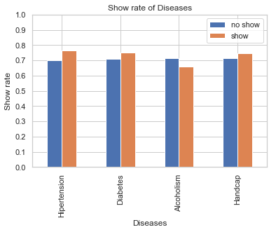

```python
# calculate and show the likelihood of show and no show with respect to diseases.
ser_hi = df_val.groupby(['Hipertension']).mean()['Show_rate']
ser_d = df_val.groupby(['Diabetes']).mean()['Show_rate']
ser_a = df_val.groupby(['Alcoholism']).mean()['Show_rate']
ser_ha = df_val.groupby(['Handcap']).mean()['Show_rate']
df_disease = pd.DataFrame({ser_hi.index.name:ser_hi.values,
                           ser_d.index.name:ser_d.values,
                           ser_a.index.name:ser_a.values,
                           ser_ha.index.name:ser_ha.values,
                          },index=['no show','show'])
print(df_disease)
df_disease.T.plot(kind='bar',y=['no show','show'],grid=True)
plt.xlabel('Diseases')
plt.ylabel('Show rate')
plt.title('Show rate of Diseases')
plt.yticks(np.arange(0,1.1,0.1))
```

- In the above graph, it is clear to see that different diseases has different show rate. The Hipertensiont disease has the highest rate 76%, and secondly Diabetes disease 75% ,and thirdly Handcap disease 74%.
- In the above graph, it is clear to see that different diseases has near the same no show rate which is 70%.

### 3.9 Show statistics related to diseases/age/scholarship

- Based on analysis above, I choose the three obviously dependent factors which contain diseases/age/scholarship to show how these variables influence the show sample distribution.

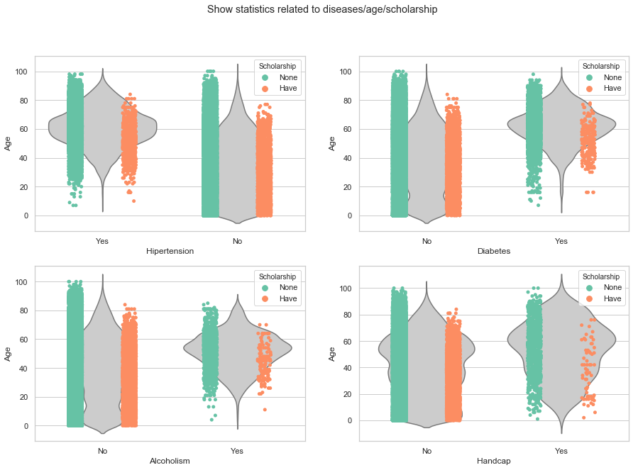

```python
# calculate and show  the sample distribution of show with respect to diseases/age/scholarship.
df_val_show = df_val[df_val['Show_rate'] == 1]
sns.set(style="whitegrid")
fig, axes = plt.subplots(nrows=2, ncols=2,figsize=(15,10))
fig.suptitle('Show statistics related to diseases/age/scholarship')
ax = sns.violinplot(x='Hipertension', y='Age', data=df_val_show,inner=None, color=".8", ax=axes[0,0])
ax = sns.stripplot(x="Hipertension", y="Age", data=df_val_show, jitter=True, hue="Scholarship", palette="Set2", dodge=True, ax=axes[0,0])

ax = sns.violinplot(x='Diabetes', y='Age', data=df_val_show,inner=None, color=".8", ax=axes[0,1])
ax = sns.stripplot(x="Diabetes", y="Age", data=df_val_show, jitter=True, hue="Scholarship", palette="Set2", dodge=True, ax=axes[0,1])

ax = sns.violinplot(x='Alcoholism', y='Age', data=df_val_show,inner=None, color=".8", ax=axes[1,0])
ax = sns.stripplot(x="Alcoholism", y="Age", data=df_val_show, jitter=True, hue="Scholarship", palette="Set2", dodge=True, ax=axes[1,0])

ax = sns.violinplot(x='Handcap', y='Age', data=df_val_show,inner=None, color=".8", ax=axes[1,1])
ax = sns.stripplot(x="Handcap", y="Age", data=df_val_show, jitter=True, hue="Scholarship", palette="Set2", dodge=True, ax=axes[1,1])
```

- All diseases have its own focused range of age.Hipertension ranges from 20 to 100 years.Diabetes ranges from 30 to 90 years.Alcoholism ranges from 20 to 90 years.Handcap ranges from 0 to 100 years.
- Scholarship condition can not affect the distribution obviously compared with none scholarship.The scholarship distribution between four diseases is quite different,especially Handcap distribution is relative dispersion along with age.
- The distribution of the show up samples with labeled specific disease shows leaf shape which means high correlation with age.
- The distribution of the show up samples with labeled none disease shows rectangle shape which means low correlation with age.

### 3.10 Show statistics related to diseases/interval/scholarship

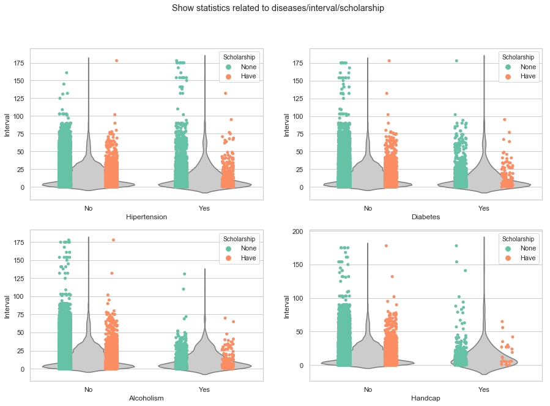

```python
# calculate and show  the sample distribution of show with respect to diseases/interval/scholarship.
df_val_show = df_val[df_val['Show_rate'] == 0]
sns.set(style="whitegrid")
fig, axes = plt.subplots(nrows=2, ncols=2,figsize=(15,10))
fig.suptitle('Show statistics related to diseases/interval/scholarship')
ax = sns.violinplot(x='Hipertension', y='Interval', data=df_val_show,inner=None, color=".8", ax=axes[0,0])
ax = sns.stripplot(x="Hipertension", y="Interval", data=df_val_show, jitter=True, hue="Scholarship", palette="Set2", dodge=True, ax=axes[0,0])

ax = sns.violinplot(x='Diabetes', y='Interval', data=df_val_show,inner=None, color=".8", ax=axes[0,1])
ax = sns.stripplot(x="Diabetes", y="Interval", data=df_val_show, jitter=True, hue="Scholarship", palette="Set2", dodge=True, ax=axes[0,1])

ax = sns.violinplot(x='Alcoholism', y='Interval', data=df_val_show,inner=None, color=".8", ax=axes[1,0])
ax = sns.stripplot(x="Alcoholism", y="Interval", data=df_val_show, jitter=True, hue="Scholarship", palette="Set2", dodge=True, ax=axes[1,0])

ax = sns.violinplot(x='Handcap', y='Interval', data=df_val_show,inner=None, color=".8", ax=axes[1,1])
ax = sns.stripplot(x="Handcap", y="Interval", data=df_val_show, jitter=True, hue="Scholarship", palette="Set2", dodge=True, ax=axes[1,1])
```

## 5.Limitations

- The high correlation factor neighbourhood can not be put into the multiple variables analysis.I think the main question to be solved is how I can forecast that show-up happen based on appointment information.I think that I need to build a model to achieve it.